# hypergeometricPres

## an example

Imagine an urn filled with 400 gold and 600 black balls all mixed up. You dip your hand in and pull out a handful(10 balls). How many of the 10 are gold?

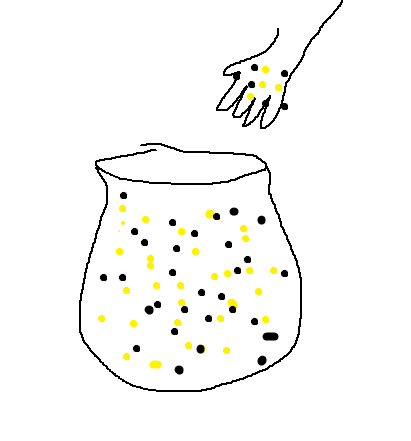

## hypergeometric distribution

If you start with an urn filled with 400 gold and 600 black balls and pull out a handful of 10 balls, the probability of winding up with *8* gold balls can be found from a hypergeometric distribution with the following parameters:

```r
  dhyper(x=8, m=400, n=600, k=10)
```

```
## [1] 0.01033436
```

## hypergeometric distribution

can we calculate the probability of pulling out all possible values of *x* gold balls out of a handful of *10*?

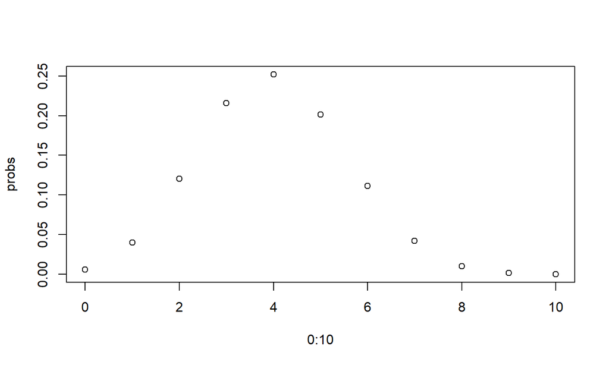

```r
  probs =  dhyper(x=0:10, m=400, n=600, k=10)
  plot(0:10, probs)
```

## hypergeometric distribution

Using the same parameters, what’s the probability of pulling out *8 or more* gold balls?

```r
  probs = dhyper(x=8:10, m=400, n=600, k=10)
  probs
```

```
## [1] 1.033436e-02 1.502901e-03 9.793903e-05
```

```r
  sum(probs)
```

```
## [1] 0.0119352
```

## Why is this important?

- Instead of thinking of gold and black balls, let’s think of significant/non-significant genes.
- In our zika example we looked at a total of *17759* genes. Of these, *2497* showed significant differential expression between groups, *17759 - 2497 = 15262* were non-significant.
- Let’s pick an arbitrary GO term from the biological processes, GO:0035308 (negative regulation of protein dephosphorylation).
- This pathway consists of *62* unique genes, and *13* of them are in our list of significant zika genes.
- How to we turn this into our hypergeometric urn problem?

## zika problem

- *2497* significant genes
- *15262* non-significant genes
- *62* genes in the go pathway
- *13* of the go pathway genes are are significant

## urn problem

- *2497* gold balls
- *15262* black balls
- *62* balls in our handful
- *13* of the balls in our hand are gold
- what’s the probability of getting 13 or more gold balls in our handful?

```r
  sum(dhyper(13:62, 2497, 15262, 62))
```

```
## [1] 0.08785213
```

## zika problem

- *2497* significant genes
- *15262* non-significant genes
- *62* genes in the go pathway
- *13* of the go pathway genes are are significant
- If we sampled 62 genes at random from our set what are the chances we’d find 13 or more significant genes?

```r
  sum(dhyper(13:62, 2497, 15262, 62))
```

```
## [1] 0.08785213
```

Is the negative regulation of protein dephosphorylation pathway over represented with genes that are associated with zika?

- That’s the p-value above!